# Risk Factor Analysis

## Outcome Variable

**Outcome Variable:** haz

## Predictor Variables

**Intervention Variable:** pers_wast

**Adjustment Set:**

- arm
- sex
- brthmon
- W_mage
- meducyrs
- hhwealth_quart
- W_nrooms
- month
- W_parity
- delta_W_mage
- delta_meducyrs
- delta_hhwealth_quart
- delta_W_nrooms
- delta_month
- delta_W_parity

## Stratifying Variables

The analysis was stratified on these variable(s):

- agecat
- studyid
- country

## Data Summary

| agecat | studyid | country | pers_wast | n_cell | n | outcome_variable |
| --- | --- | --- | --- | --- | --- | --- |
| Birth | CMC-V-BCS-2002 | INDIA | 0 | 80 | 92 | haz |
| Birth | CMC-V-BCS-2002 | INDIA | 1 | 12 | 92 | haz |
| Birth | CMIN | BANGLADESH | 0 | 16 | 18 | haz |
| Birth | CMIN | BANGLADESH | 1 | 2 | 18 | haz |
| Birth | CONTENT | PERU | 0 | 2 | 2 | haz |
| Birth | CONTENT | PERU | 1 | 0 | 2 | haz |
| Birth | EE | PAKISTAN | 0 | 224 | 240 | haz |
| Birth | EE | PAKISTAN | 1 | 16 | 240 | haz |
| Birth | GMS-Nepal | NEPAL | 0 | 521 | 585 | haz |
| Birth | GMS-Nepal | NEPAL | 1 | 64 | 585 | haz |
| Birth | IRC | INDIA | 0 | 319 | 387 | haz |
| Birth | IRC | INDIA | 1 | 68 | 387 | haz |
| Birth | Keneba | GAMBIA | 0 | 1374 | 1419 | haz |
| Birth | Keneba | GAMBIA | 1 | 45 | 1419 | haz |
| Birth | MAL-ED | BANGLADESH | 0 | 220 | 229 | haz |
| Birth | MAL-ED | BANGLADESH | 1 | 9 | 229 | haz |
| Birth | MAL-ED | BRAZIL | 0 | 65 | 65 | haz |
| Birth | MAL-ED | BRAZIL | 1 | 0 | 65 | haz |
| Birth | MAL-ED | INDIA | 0 | 43 | 45 | haz |
| Birth | MAL-ED | INDIA | 1 | 2 | 45 | haz |
| Birth | MAL-ED | NEPAL | 0 | 26 | 27 | haz |
| Birth | MAL-ED | NEPAL | 1 | 1 | 27 | haz |
| Birth | MAL-ED | PERU | 0 | 233 | 233 | haz |
| Birth | MAL-ED | PERU | 1 | 0 | 233 | haz |
| Birth | MAL-ED | SOUTH AFRICA | 0 | 111 | 113 | haz |
| Birth | MAL-ED | SOUTH AFRICA | 1 | 2 | 113 | haz |
| Birth | MAL-ED | TANZANIA, UNITED REPUBLIC OF | 0 | 123 | 123 | haz |
| Birth | MAL-ED | TANZANIA, UNITED REPUBLIC OF | 1 | 0 | 123 | haz |
| Birth | PROVIDE | BANGLADESH | 0 | 516 | 539 | haz |
| Birth | PROVIDE | BANGLADESH | 1 | 23 | 539 | haz |

[output cut: 70 more lines]

The following strata were considered:

- agecat: 24 months, studyid: CMC-V-BCS-2002, country: INDIA
- agecat: 24 months, studyid: CMIN, country: BANGLADESH
- agecat: 24 months, studyid: CONTENT, country: PERU
- agecat: 24 months, studyid: EE, country: PAKISTAN
- agecat: 24 months, studyid: GMS-Nepal, country: NEPAL
- agecat: 24 months, studyid: IRC, country: INDIA
- agecat: 24 months, studyid: Keneba, country: GAMBIA
- agecat: 24 months, studyid: MAL-ED, country: BANGLADESH
- agecat: 24 months, studyid: MAL-ED, country: BRAZIL
- agecat: 24 months, studyid: MAL-ED, country: INDIA
- agecat: 24 months, studyid: MAL-ED, country: NEPAL
- agecat: 24 months, studyid: MAL-ED, country: PERU
- agecat: 24 months, studyid: MAL-ED, country: SOUTH AFRICA
- agecat: 24 months, studyid: MAL-ED, country: TANZANIA, UNITED REPUBLIC OF
- agecat: 24 months, studyid: PROVIDE, country: BANGLADESH
- agecat: 24 months, studyid: TanzaniaChild2, country: TANZANIA, UNITED REPUBLIC OF
- agecat: 6 months, studyid: CMC-V-BCS-2002, country: INDIA
- agecat: 6 months, studyid: CMIN, country: BANGLADESH
- agecat: 6 months, studyid: CONTENT, country: PERU
- agecat: 6 months, studyid: EE, country: PAKISTAN
- agecat: 6 months, studyid: GMS-Nepal, country: NEPAL
- agecat: 6 months, studyid: Guatemala BSC, country: GUATEMALA
- agecat: 6 months, studyid: IRC, country: INDIA
- agecat: 6 months, studyid: Keneba, country: GAMBIA
- agecat: 6 months, studyid: MAL-ED, country: BANGLADESH
- agecat: 6 months, studyid: MAL-ED, country: BRAZIL
- agecat: 6 months, studyid: MAL-ED, country: INDIA
- agecat: 6 months, studyid: MAL-ED, country: NEPAL
- agecat: 6 months, studyid: MAL-ED, country: PERU
- agecat: 6 months, studyid: MAL-ED, country: SOUTH AFRICA
- agecat: 6 months, studyid: MAL-ED, country: TANZANIA, UNITED REPUBLIC OF
- agecat: 6 months, studyid: PROVIDE, country: BANGLADESH
- agecat: 6 months, studyid: ResPak, country: PAKISTAN
- agecat: 6 months, studyid: TanzaniaChild2, country: TANZANIA, UNITED REPUBLIC OF
- agecat: Birth, studyid: CMC-V-BCS-2002, country: INDIA
- agecat: Birth, studyid: CMIN, country: BANGLADESH
- agecat: Birth, studyid: CONTENT, country: PERU
- agecat: Birth, studyid: EE, country: PAKISTAN
- agecat: Birth, studyid: GMS-Nepal, country: NEPAL
- agecat: Birth, studyid: IRC, country: INDIA
- agecat: Birth, studyid: Keneba, country: GAMBIA
- agecat: Birth, studyid: MAL-ED, country: BANGLADESH
- agecat: Birth, studyid: MAL-ED, country: BRAZIL
- agecat: Birth, studyid: MAL-ED, country: INDIA
- agecat: Birth, studyid: MAL-ED, country: NEPAL
- agecat: Birth, studyid: MAL-ED, country: PERU
- agecat: Birth, studyid: MAL-ED, country: SOUTH AFRICA
- agecat: Birth, studyid: MAL-ED, country: TANZANIA, UNITED REPUBLIC OF
- agecat: Birth, studyid: PROVIDE, country: BANGLADESH
- agecat: Birth, studyid: ResPak, country: PAKISTAN

### Dropped Strata

Some strata were dropped due to rare outcomes:

- agecat: Birth, studyid: CMIN, country: BANGLADESH
- agecat: Birth, studyid: CONTENT, country: PERU
- agecat: Birth, studyid: MAL-ED, country: BRAZIL
- agecat: Birth, studyid: MAL-ED, country: INDIA
- agecat: Birth, studyid: MAL-ED, country: NEPAL
- agecat: Birth, studyid: MAL-ED, country: PERU
- agecat: Birth, studyid: MAL-ED, country: SOUTH AFRICA
- agecat: Birth, studyid: MAL-ED, country: TANZANIA, UNITED REPUBLIC OF
- agecat: Birth, studyid: ResPak, country: PAKISTAN
- agecat: 6 months, studyid: CONTENT, country: PERU
- agecat: 6 months, studyid: MAL-ED, country: BRAZIL
- agecat: 6 months, studyid: MAL-ED, country: PERU
- agecat: 6 months, studyid: MAL-ED, country: SOUTH AFRICA
- agecat: 6 months, studyid: MAL-ED, country: TANZANIA, UNITED REPUBLIC OF
- agecat: 24 months, studyid: CONTENT, country: PERU
- agecat: 24 months, studyid: MAL-ED, country: BRAZIL
- agecat: 24 months, studyid: MAL-ED, country: PERU
- agecat: 24 months, studyid: MAL-ED, country: SOUTH AFRICA
- agecat: 24 months, studyid: MAL-ED, country: TANZANIA, UNITED REPUBLIC OF
- agecat: 24 months, studyid: TanzaniaChild2, country: TANZANIA, UNITED REPUBLIC OF

## Methods Detail

We’re interested in the causal parameters $E[Y_a]$ for all values of $a \in \mathcal{A}$. These parameters represent the mean outcome if, possibly contrary to fact, we intervened to set all units to have $A=a$. Under the randomization and positivity assumptions, these are identified by the statistical parameters $\psi_a=E_W[E_{Y|A,W}(Y|A=a,W)]$. In addition, we’re interested in the mean of $Y$, $E[Y]$ under no intervention (the observed mean). We will estimate these parameters by using SuperLearner to fit the relevant likelihood factors – $E_{Y|A,W}(Y|A=a,W)$ and $p(A=a|W)$, and then updating our likelihood fit using a joint TMLE.

For unadjusted analyses ($W=\{\}$), initial likelihoods were estimated using Lrnr_glm to estimate the simple $E(Y|A)$ and Lrnr_mean to estimate $p(A)$. For adjusted analyses, a small library containing Lrnr_glmnet, Lrnr_xgboost, and Lrnr_mean was used.

Having estimated these parameters, we will then use the delta method to estimate relative risks and attributable risks relative to a prespecified baseline level of $A$.

# Results Detail

## Results Plots

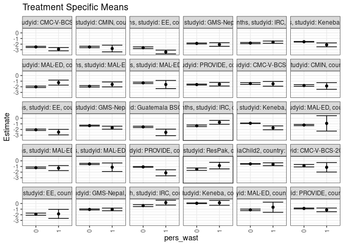

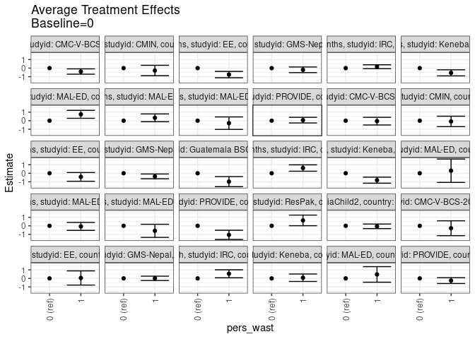

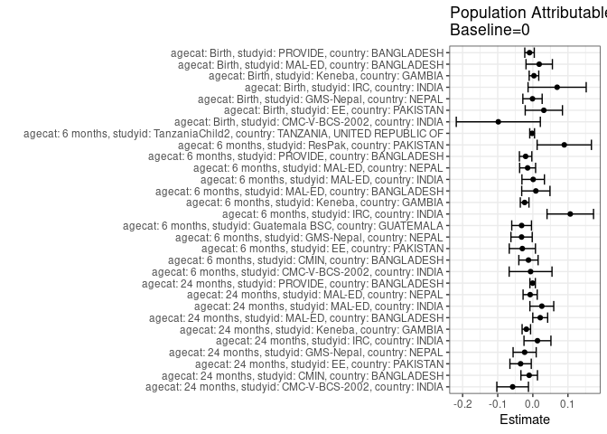

## Results Table

### Parameter: TSM

| agecat | studyid | country | intervention_level | baseline_level | estimate | ci_lower | ci_upper |
| --- | --- | --- | --- | --- | --- | --- | --- |
| Birth | CMC-V-BCS-2002 | INDIA | 0 | NA | -0.8628411 | -1.0776602 | -0.6480221 |
| Birth | CMC-V-BCS-2002 | INDIA | 1 | NA | -1.1448455 | -1.9823180 | -0.3073729 |
| Birth | EE | PAKISTAN | 0 | NA | -1.8922119 | -2.0861146 | -1.6983092 |
| Birth | EE | PAKISTAN | 1 | NA | -1.8434470 | -2.6463055 | -1.0405885 |
| Birth | GMS-Nepal | NEPAL | 0 | NA | -1.0545118 | -1.1464664 | -0.9625572 |
| Birth | GMS-Nepal | NEPAL | 1 | NA | -1.0487608 | -1.2851335 | -0.8123881 |
| Birth | IRC | INDIA | 0 | NA | -0.3809484 | -0.5529847 | -0.2089122 |
| Birth | IRC | INDIA | 1 | NA | 0.1561628 | -0.2772840 | 0.5896096 |
| Birth | Keneba | GAMBIA | 0 | NA | 0.0399916 | -0.0269564 | 0.1069396 |
| Birth | Keneba | GAMBIA | 1 | NA | 0.1177420 | -0.3107624 | 0.5462465 |
| Birth | MAL-ED | BANGLADESH | 0 | NA | -1.1222727 | -1.2564846 | -0.9880609 |
| Birth | MAL-ED | BANGLADESH | 1 | NA | -0.6600000 | -1.5592093 | 0.2392093 |
| Birth | PROVIDE | BANGLADESH | 0 | NA | -0.8757006 | -0.9532178 | -0.7981834 |
| Birth | PROVIDE | BANGLADESH | 1 | NA | -1.1343554 | -1.4662930 | -0.8024177 |
| 6 months | CMC-V-BCS-2002 | INDIA | 0 | NA | -1.4177873 | -1.5714959 | -1.2640786 |
| 6 months | CMC-V-BCS-2002 | INDIA | 1 | NA | -1.4724435 | -1.8934822 | -1.0514047 |
| 6 months | CMIN | BANGLADESH | 0 | NA | -1.7719977 | -1.9138754 | -1.6301199 |
| 6 months | CMIN | BANGLADESH | 1 | NA | -1.8565895 | -2.4487934 | -1.2643857 |
| 6 months | EE | PAKISTAN | 0 | NA | -2.0536968 | -2.1760220 | -1.9313716 |
| 6 months | EE | PAKISTAN | 1 | NA | -2.4790898 | -2.9739821 | -1.9841976 |
| 6 months | GMS-Nepal | NEPAL | 0 | NA | -1.3212567 | -1.4032048 | -1.2393086 |
| 6 months | GMS-Nepal | NEPAL | 1 | NA | -1.6876384 | -1.9539401 | -1.4213367 |
| 6 months | Guatemala BSC | GUATEMALA | 0 | NA | -1.5415418 | -1.6567941 | -1.4262896 |
| 6 months | Guatemala BSC | GUATEMALA | 1 | NA | -2.5211111 | -3.0985428 | -1.9436794 |
| 6 months | IRC | INDIA | 0 | NA | -1.3449794 | -1.4850744 | -1.2048844 |
| 6 months | IRC | INDIA | 1 | NA | -0.7336860 | -1.0786126 | -0.3887594 |
| 6 months | Keneba | GAMBIA | 0 | NA | -0.9048815 | -0.9537661 | -0.8559968 |
| 6 months | Keneba | GAMBIA | 1 | NA | -1.7140999 | -2.0641169 | -1.3640828 |
| 6 months | MAL-ED | BANGLADESH | 0 | NA | -1.2135826 | -1.3270160 | -1.1001493 |
| 6 months | MAL-ED | BANGLADESH | 1 | NA | -0.9178571 | -2.2823123 | 0.4465980 |
| 6 months | MAL-ED | INDIA | 0 | NA | -1.2125069 | -1.3366172 | -1.0883967 |
| 6 months | MAL-ED | INDIA | 1 | NA | -1.2820360 | -1.7275519 | -0.8365200 |
| 6 months | MAL-ED | NEPAL | 0 | NA | -0.5467101 | -0.6599035 | -0.4335168 |
| 6 months | MAL-ED | NEPAL | 1 | NA | -1.1316667 | -1.8892005 | -0.3741328 |
| 6 months | PROVIDE | BANGLADESH | 0 | NA | -1.0711707 | -1.1456972 | -0.9966441 |
| 6 months | PROVIDE | BANGLADESH | 1 | NA | -2.1264542 | -2.6605980 | -1.5923104 |
| 6 months | ResPak | PAKISTAN | 0 | NA | -1.4770253 | -1.6966266 | -1.2574239 |
| 6 months | ResPak | PAKISTAN | 1 | NA | -0.8440881 | -1.4259920 | -0.2621842 |
| 6 months | TanzaniaChild2 | TANZANIA, UNITED REPUBLIC OF | 0 | NA | -0.5430927 | -0.5930357 | -0.4931497 |
| 6 months | TanzaniaChild2 | TANZANIA, UNITED REPUBLIC OF | 1 | NA | -0.6023628 | -0.8629292 | -0.3417965 |
| 24 months | CMC-V-BCS-2002 | INDIA | 0 | NA | -2.4913769 | -2.5952974 | -2.3874564 |
| 24 months | CMC-V-BCS-2002 | INDIA | 1 | NA | -2.8895067 | -3.1826840 | -2.5963295 |
| 24 months | CMIN | BANGLADESH | 0 | NA | -2.5005794 | -2.6283894 | -2.3727694 |
| 24 months | CMIN | BANGLADESH | 1 | NA | -2.7794444 | -3.3734067 | -2.1854822 |
| 24 months | EE | PAKISTAN | 0 | NA | -2.6351256 | -2.7860371 | -2.4842142 |
| 24 months | EE | PAKISTAN | 1 | NA | -3.3922991 | -3.7296801 | -3.0549181 |
| 24 months | GMS-Nepal | NEPAL | 0 | NA | -1.8705520 | -1.9593552 | -1.7817487 |
| 24 months | GMS-Nepal | NEPAL | 1 | NA | -2.0674590 | -2.3844082 | -1.7505098 |
| 24 months | IRC | INDIA | 0 | NA | -1.8121407 | -1.9172128 | -1.7070685 |
| 24 months | IRC | INDIA | 1 | NA | -1.6489460 | -1.8490881 | -1.4488040 |
| 24 months | Keneba | GAMBIA | 0 | NA | -1.5739333 | -1.6281397 | -1.5197269 |
| 24 months | Keneba | GAMBIA | 1 | NA | -2.1251160 | -2.4757189 | -1.7745131 |
| 24 months | MAL-ED | BANGLADESH | 0 | NA | -1.9994417 | -2.1279716 | -1.8709119 |
| 24 months | MAL-ED | BANGLADESH | 1 | NA | -1.2558333 | -1.7012482 | -0.8104185 |
| 24 months | MAL-ED | INDIA | 0 | NA | -1.9118123 | -2.0428057 | -1.7808189 |
| 24 months | MAL-ED | INDIA | 1 | NA | -1.5774174 | -2.0142073 | -1.1406276 |
| 24 months | MAL-ED | NEPAL | 0 | NA | -1.2999550 | -1.4209558 | -1.1789541 |
| 24 months | MAL-ED | NEPAL | 1 | NA | -1.5900000 | -2.3102086 | -0.8697914 |
| 24 months | PROVIDE | BANGLADESH | 0 | NA | -1.6018229 | -1.6869392 | -1.5167067 |
| 24 months | PROVIDE | BANGLADESH | 1 | NA | -1.5368850 | -1.8563183 | -1.2174517 |

### Parameter: E(Y)

| agecat | studyid | country | intervention_level | baseline_level | estimate | ci_lower | ci_upper |
| --- | --- | --- | --- | --- | --- | --- | --- |
| Birth | CMC-V-BCS-2002 | INDIA | NA | NA | -0.9611957 | -1.1776967 | -0.7446946 |
| Birth | EE | PAKISTAN | NA | NA | -1.8608750 | -2.0482045 | -1.6735455 |
| Birth | GMS-Nepal | NEPAL | NA | NA | -1.0554530 | -1.1411259 | -0.9697801 |
| Birth | IRC | INDIA | NA | NA | -0.3117313 | -0.4727359 | -0.1507267 |
| Birth | Keneba | GAMBIA | NA | NA | 0.0432135 | -0.0229516 | 0.1093787 |
| Birth | MAL-ED | BANGLADESH | NA | NA | -1.1041048 | -1.2383048 | -0.9699048 |
| Birth | PROVIDE | BANGLADESH | NA | NA | -0.8851020 | -0.9601332 | -0.8100709 |
| 6 months | CMC-V-BCS-2002 | INDIA | NA | NA | -1.4241872 | -1.5668135 | -1.2815609 |
| 6 months | CMIN | BANGLADESH | NA | NA | -1.7844376 | -1.9222926 | -1.6465825 |
| 6 months | EE | PAKISTAN | NA | NA | -2.0835567 | -2.2027557 | -1.9643578 |
| 6 months | GMS-Nepal | NEPAL | NA | NA | -1.3533244 | -1.4319426 | -1.2747062 |
| 6 months | Guatemala BSC | GUATEMALA | NA | NA | -1.5734843 | -1.6884116 | -1.4585570 |
| 6 months | IRC | INDIA | NA | NA | -1.2382964 | -1.3698449 | -1.1067479 |
| 6 months | Keneba | GAMBIA | NA | NA | -0.9282048 | -0.9770928 | -0.8793169 |
| 6 months | MAL-ED | BANGLADESH | NA | NA | -1.2049931 | -1.3222136 | -1.0877726 |
| 6 months | MAL-ED | INDIA | NA | NA | -1.2115254 | -1.3298727 | -1.0931782 |
| 6 months | MAL-ED | NEPAL | NA | NA | -0.5615819 | -0.6741832 | -0.4489807 |
| 6 months | PROVIDE | BANGLADESH | NA | NA | -1.0916915 | -1.1661176 | -1.0172654 |
| 6 months | ResPak | PAKISTAN | NA | NA | -1.3874523 | -1.5959323 | -1.1789723 |
| 6 months | TanzaniaChild2 | TANZANIA, UNITED REPUBLIC OF | NA | NA | -0.5450830 | -0.5941754 | -0.4959906 |
| 24 months | CMC-V-BCS-2002 | INDIA | NA | NA | -2.5489071 | -2.6476125 | -2.4502017 |
| 24 months | CMIN | BANGLADESH | NA | NA | -2.5109504 | -2.6361514 | -2.3857494 |
| 24 months | EE | PAKISTAN | NA | NA | -2.6699900 | -2.8138051 | -2.5261749 |
| 24 months | GMS-Nepal | NEPAL | NA | NA | -1.8938622 | -1.9795205 | -1.8082040 |
| 24 months | IRC | INDIA | NA | NA | -1.7989338 | -1.8927769 | -1.7050907 |
| 24 months | Keneba | GAMBIA | NA | NA | -1.5924094 | -1.6461889 | -1.5386298 |
| 24 months | MAL-ED | BANGLADESH | NA | NA | -1.9783962 | -2.1050210 | -1.8517715 |
| 24 months | MAL-ED | INDIA | NA | NA | -1.8861894 | -2.0110006 | -1.7613783 |
| 24 months | MAL-ED | NEPAL | NA | NA | -1.3075877 | -1.4270718 | -1.1881037 |
| 24 months | PROVIDE | BANGLADESH | NA | NA | -1.6024221 | -1.6857420 | -1.5191023 |

### Parameter: ATE

| agecat | studyid | country | intervention_level | baseline_level | estimate | ci_lower | ci_upper |
| --- | --- | --- | --- | --- | --- | --- | --- |
| Birth | CMC-V-BCS-2002 | INDIA | 0 | 0 | 0.0000000 | 0.0000000 | 0.0000000 |
| Birth | CMC-V-BCS-2002 | INDIA | 1 | 0 | -0.2820043 | -1.1503554 | 0.5863468 |
| Birth | EE | PAKISTAN | 0 | 0 | 0.0000000 | 0.0000000 | 0.0000000 |
| Birth | EE | PAKISTAN | 1 | 0 | 0.0487649 | -0.7814395 | 0.8789694 |
| Birth | GMS-Nepal | NEPAL | 0 | 0 | 0.0000000 | 0.0000000 | 0.0000000 |
| Birth | GMS-Nepal | NEPAL | 1 | 0 | 0.0057510 | -0.2481782 | 0.2596803 |
| Birth | IRC | INDIA | 0 | 0 | 0.0000000 | 0.0000000 | 0.0000000 |
| Birth | IRC | INDIA | 1 | 0 | 0.5371112 | 0.0690973 | 1.0051251 |
| Birth | Keneba | GAMBIA | 0 | 0 | 0.0000000 | 0.0000000 | 0.0000000 |
| Birth | Keneba | GAMBIA | 1 | 0 | 0.0777504 | -0.3560745 | 0.5115753 |
| Birth | MAL-ED | BANGLADESH | 0 | 0 | 0.0000000 | 0.0000000 | 0.0000000 |
| Birth | MAL-ED | BANGLADESH | 1 | 0 | 0.4622727 | -0.4468973 | 1.3714428 |
| Birth | PROVIDE | BANGLADESH | 0 | 0 | 0.0000000 | 0.0000000 | 0.0000000 |
| Birth | PROVIDE | BANGLADESH | 1 | 0 | -0.2586548 | -0.5991436 | 0.0818341 |
| 6 months | CMC-V-BCS-2002 | INDIA | 0 | 0 | 0.0000000 | 0.0000000 | 0.0000000 |
| 6 months | CMC-V-BCS-2002 | INDIA | 1 | 0 | -0.0546562 | -0.5039897 | 0.3946772 |
| 6 months | CMIN | BANGLADESH | 0 | 0 | 0.0000000 | 0.0000000 | 0.0000000 |
| 6 months | CMIN | BANGLADESH | 1 | 0 | -0.0845919 | -0.6936890 | 0.5245053 |
| 6 months | EE | PAKISTAN | 0 | 0 | 0.0000000 | 0.0000000 | 0.0000000 |
| 6 months | EE | PAKISTAN | 1 | 0 | -0.4253930 | -0.9353933 | 0.0846072 |
| 6 months | GMS-Nepal | NEPAL | 0 | 0 | 0.0000000 | 0.0000000 | 0.0000000 |
| 6 months | GMS-Nepal | NEPAL | 1 | 0 | -0.3663817 | -0.6449006 | -0.0878627 |
| 6 months | Guatemala BSC | GUATEMALA | 0 | 0 | 0.0000000 | 0.0000000 | 0.0000000 |
| 6 months | Guatemala BSC | GUATEMALA | 1 | 0 | -0.9795693 | -1.5683905 | -0.3907481 |
| 6 months | IRC | INDIA | 0 | 0 | 0.0000000 | 0.0000000 | 0.0000000 |
| 6 months | IRC | INDIA | 1 | 0 | 0.6112934 | 0.2388434 | 0.9837433 |
| 6 months | Keneba | GAMBIA | 0 | 0 | 0.0000000 | 0.0000000 | 0.0000000 |
| 6 months | Keneba | GAMBIA | 1 | 0 | -0.8092184 | -1.1628136 | -0.4556232 |
| 6 months | MAL-ED | BANGLADESH | 0 | 0 | 0.0000000 | 0.0000000 | 0.0000000 |
| 6 months | MAL-ED | BANGLADESH | 1 | 0 | 0.2957255 | -1.0734367 | 1.6648877 |
| 6 months | MAL-ED | INDIA | 0 | 0 | 0.0000000 | 0.0000000 | 0.0000000 |
| 6 months | MAL-ED | INDIA | 1 | 0 | -0.0695290 | -0.5325628 | 0.3935048 |
| 6 months | MAL-ED | NEPAL | 0 | 0 | 0.0000000 | 0.0000000 | 0.0000000 |
| 6 months | MAL-ED | NEPAL | 1 | 0 | -0.5849565 | -1.3509005 | 0.1809875 |
| 6 months | PROVIDE | BANGLADESH | 0 | 0 | 0.0000000 | 0.0000000 | 0.0000000 |
| 6 months | PROVIDE | BANGLADESH | 1 | 0 | -1.0552835 | -1.5944208 | -0.5161462 |
| 6 months | ResPak | PAKISTAN | 0 | 0 | 0.0000000 | 0.0000000 | 0.0000000 |
| 6 months | ResPak | PAKISTAN | 1 | 0 | 0.6329372 | 0.0118448 | 1.2540295 |
| 6 months | TanzaniaChild2 | TANZANIA, UNITED REPUBLIC OF | 0 | 0 | 0.0000000 | 0.0000000 | 0.0000000 |
| 6 months | TanzaniaChild2 | TANZANIA, UNITED REPUBLIC OF | 1 | 0 | -0.0592702 | -0.3245113 | 0.2059710 |
| 24 months | CMC-V-BCS-2002 | INDIA | 0 | 0 | 0.0000000 | 0.0000000 | 0.0000000 |
| 24 months | CMC-V-BCS-2002 | INDIA | 1 | 0 | -0.3981299 | -0.7088788 | -0.0873809 |
| 24 months | CMIN | BANGLADESH | 0 | 0 | 0.0000000 | 0.0000000 | 0.0000000 |
| 24 months | CMIN | BANGLADESH | 1 | 0 | -0.2788650 | -0.8864229 | 0.3286928 |
| 24 months | EE | PAKISTAN | 0 | 0 | 0.0000000 | 0.0000000 | 0.0000000 |
| 24 months | EE | PAKISTAN | 1 | 0 | -0.7571734 | -1.1284585 | -0.3858883 |
| 24 months | GMS-Nepal | NEPAL | 0 | 0 | 0.0000000 | 0.0000000 | 0.0000000 |
| 24 months | GMS-Nepal | NEPAL | 1 | 0 | -0.1969070 | -0.5264279 | 0.1326138 |
| 24 months | IRC | INDIA | 0 | 0 | 0.0000000 | 0.0000000 | 0.0000000 |
| 24 months | IRC | INDIA | 1 | 0 | 0.1631947 | -0.0624743 | 0.3888636 |
| 24 months | Keneba | GAMBIA | 0 | 0 | 0.0000000 | 0.0000000 | 0.0000000 |
| 24 months | Keneba | GAMBIA | 1 | 0 | -0.5511827 | -0.9061331 | -0.1962323 |
| 24 months | MAL-ED | BANGLADESH | 0 | 0 | 0.0000000 | 0.0000000 | 0.0000000 |
| 24 months | MAL-ED | BANGLADESH | 1 | 0 | 0.7436084 | 0.2800199 | 1.2071969 |
| 24 months | MAL-ED | INDIA | 0 | 0 | 0.0000000 | 0.0000000 | 0.0000000 |
| 24 months | MAL-ED | INDIA | 1 | 0 | 0.3343949 | -0.1197570 | 0.7885467 |
| 24 months | MAL-ED | NEPAL | 0 | 0 | 0.0000000 | 0.0000000 | 0.0000000 |
| 24 months | MAL-ED | NEPAL | 1 | 0 | -0.2900450 | -1.0203475 | 0.4402574 |
| 24 months | PROVIDE | BANGLADESH | 0 | 0 | 0.0000000 | 0.0000000 | 0.0000000 |
| 24 months | PROVIDE | BANGLADESH | 1 | 0 | 0.0649379 | -0.2657023 | 0.3955781 |

### Parameter: PAR

| agecat | studyid | country | intervention_level | baseline_level | estimate | ci_lower | ci_upper |
| --- | --- | --- | --- | --- | --- | --- | --- |
| Birth | CMC-V-BCS-2002 | INDIA | 0 | NA | -0.0983545 | -0.2180729 | 0.0213639 |
| Birth | EE | PAKISTAN | 0 | NA | 0.0313369 | -0.0217194 | 0.0843931 |
| Birth | GMS-Nepal | NEPAL | 0 | NA | -0.0009412 | -0.0284223 | 0.0265400 |
| Birth | IRC | INDIA | 0 | NA | 0.0692172 | -0.0135728 | 0.1520071 |
| Birth | Keneba | GAMBIA | 0 | NA | 0.0032219 | -0.0104313 | 0.0168751 |
| Birth | MAL-ED | BANGLADESH | 0 | NA | 0.0181679 | -0.0194178 | 0.0557537 |
| Birth | PROVIDE | BANGLADESH | 0 | NA | -0.0094014 | -0.0229141 | 0.0041113 |
| 6 months | CMC-V-BCS-2002 | INDIA | 0 | NA | -0.0063999 | -0.0674159 | 0.0546160 |
| 6 months | CMIN | BANGLADESH | 0 | NA | -0.0124399 | -0.0398552 | 0.0149754 |
| 6 months | EE | PAKISTAN | 0 | NA | -0.0298600 | -0.0671825 | 0.0074625 |
| 6 months | GMS-Nepal | NEPAL | 0 | NA | -0.0320677 | -0.0623850 | -0.0017504 |
| 6 months | Guatemala BSC | GUATEMALA | 0 | NA | -0.0319425 | -0.0600761 | -0.0038089 |
| 6 months | IRC | INDIA | 0 | NA | 0.1066830 | 0.0404526 | 0.1729134 |
| 6 months | Keneba | GAMBIA | 0 | NA | -0.0233234 | -0.0356438 | -0.0110030 |
| 6 months | MAL-ED | BANGLADESH | 0 | NA | 0.0085895 | -0.0316719 | 0.0488510 |
| 6 months | MAL-ED | INDIA | 0 | NA | 0.0009815 | -0.0310485 | 0.0330115 |
| 6 months | MAL-ED | NEPAL | 0 | NA | -0.0148718 | -0.0376268 | 0.0078833 |
| 6 months | PROVIDE | BANGLADESH | 0 | NA | -0.0205208 | -0.0382058 | -0.0028358 |
| 6 months | ResPak | PAKISTAN | 0 | NA | 0.0895730 | 0.0122631 | 0.1668829 |
| 6 months | TanzaniaChild2 | TANZANIA, UNITED REPUBLIC OF | 0 | NA | -0.0019903 | -0.0088043 | 0.0048237 |
| 24 months | CMC-V-BCS-2002 | INDIA | 0 | NA | -0.0575302 | -0.1025452 | -0.0125152 |
| 24 months | CMIN | BANGLADESH | 0 | NA | -0.0103710 | -0.0339279 | 0.0131858 |
| 24 months | EE | PAKISTAN | 0 | NA | -0.0348644 | -0.0652676 | -0.0044611 |
| 24 months | GMS-Nepal | NEPAL | 0 | NA | -0.0233103 | -0.0562297 | 0.0096092 |
| 24 months | IRC | INDIA | 0 | NA | 0.0132069 | -0.0251601 | 0.0515739 |
| 24 months | Keneba | GAMBIA | 0 | NA | -0.0184761 | -0.0305251 | -0.0064271 |
| 24 months | MAL-ED | BANGLADESH | 0 | NA | 0.0210455 | -0.0001441 | 0.0422351 |
| 24 months | MAL-ED | INDIA | 0 | NA | 0.0256229 | -0.0083009 | 0.0595466 |
| 24 months | MAL-ED | NEPAL | 0 | NA | -0.0076328 | -0.0277780 | 0.0125124 |
| 24 months | PROVIDE | BANGLADESH | 0 | NA | -0.0005992 | -0.0083532 | 0.0071548 |